# Lecture 17

# Lecture 17 Natural Language Processing (I)

### Outline

1. TextBlob and Tokenization
2. Sentiment Analysis

# 1. TextBlob and Tokenization

*TextBlob* is a Python library for processing textual data. We need to install *TextBlob* in command prompt (or terminal) using

**pip install textblob**

In addition, we need to execute the following command to download the NLTK corpora used by TextBlob.

**python -m textblob.download_corpora**

Once installation completes, we import from the library the fundamental class for natural language processing (NLP) --- *TextBlob*.

```python
from textblob import TextBlob
```

The text we use here is a Jane Jacobs quote from her *The Death and Life of Great American Cities, Chapter 5 The use of neighborhood parks, pp 106*:

```python
text =  "the presence of buildings around a park is important in " \
"design. They enclose it. They make a definite shape out of the space," \
"so that it appears as an important event in the city scene, a positive " \
"feature, rather than a no-account leftover."
```

## 1.1 Create a TextBlob

First, we create a *TextBlob* object for the text.

```python
blob = TextBlob(text)
blob
```

```
TextBlob("the presence of buildings around a park is important in design. They enclose it. They make a definite shape out of the space,so that it appears as an important event in the city scene, a positive feature, rather than a no-account leftover.")
```

```python
type(blob)
```

```
textblob.blob.TextBlob
```

This *TextBlob* object has many useful methods we will explore for our NLP purpose. Note that this object also supports string methods. In another word, you can manipulate it as a string.

```python
blob + 'Test'
```

```
TextBlob("the presence of buildings around a park is important in design. They enclose it. They make a definite shape out of the space,so that it appears as an important event in the city scene, a positive feature, rather than a no-account leftover.Test")
```

```python
len(blob)
```

```
239
```

```python
blob[58]
```

```
's'
```

```python
blob.find('park')
```

```
35
```

## 1.2 Tokenization

Tokenization is to split text into pieces called "tokens", which are meaningful units, such as words and sentences. *TextBlob* provides convenient ways to access the sentences and words of a text.

We can use *.sentences* to get a list of *Sentence* object.

```python
blob.sentences
```

```
[Sentence("the presence of buildings around a park is important in design."),
 Sentence("They enclose it."),
 Sentence("They make a definite shape out of the space,so that it appears as an important event in the city scene, a positive feature, rather than a no-account leftover.")]
```

We can use *.words* to get a *WordList* object, containing a list of all words in the text. All punctuations are removed.

```python
blob.words
```

```
WordList(['the', 'presence', 'of', 'buildings', 'around', 'a', 'park', 'is', 'important', 'in', 'design', 'They', 'enclose', 'it', 'They', 'make', 'a', 'definite', 'shape', 'out', 'of', 'the', 'space', 'so', 'that', 'it', 'appears', 'as', 'an', 'important', 'event', 'in', 'the', 'city', 'scene', 'a'…
```

## 1.3 Parts-of-Speech (POS) Tagging

There are 8 primary English parts of speech:

```
* noun
* pronoun
* verb
* adjective
* adverb
* preposition
* conjunction
* interjection
```

Many words have multiple meanings. For example, "design" can be a noun or a verb. Determining a word's meaning in the sentence is very important for computers to undertand natural languages. POS tagging is for this purpose.

We can apply *.tags* to a *Sentence* or a *Textblob* object.

```python
blob.sentences[0].tags
```

```
[('the', 'DT'),
 ('presence', 'NN'),
 ('of', 'IN'),
 ('buildings', 'NNS'),
 ('around', 'IN'),
 ('a', 'DT'),
 ('park', 'NN'),
 ('is', 'VBZ'),
 ('important', 'JJ'),
 ('in', 'IN'),
 ('design', 'NN')]
```

```python
print(blob.tags)
```

```
[('the', 'DT'), ('presence', 'NN'), ('of', 'IN'), ('buildings', 'NNS'), ('around', 'IN'), ('a', 'DT'), ('park', 'NN'), ('is', 'VBZ'), ('important', 'JJ'), ('in', 'IN'), ('design', 'NN'), ('They', 'PRP'), ('enclose', 'VBP'), ('it', 'PRP'), ('They', 'PRP'), ('make', 'VBP'), ('a', 'DT'), ('definite', '…
```

We can see that "design" is tagged "NN" which means a noun. The tag list can be found in https://www.clips.uantwerpen.be/pages/MBSP-tags. This is the website for the *pattern library* which provides the capability for TextBlob to conduct POS tagging.

## 1.4 Extracting noun phrases

Sometimes, we care more about noun phrases instead of each single noun.

```python
blob
```

```
TextBlob("the presence of buildings around a park is important in design. They enclose it. They make a definite shape out of the space,so that it appears as an important event in the city scene, a positive feature, rather than a no-account leftover.")
```

```python
blob.noun_phrases
```

```
WordList(['definite shape', 'important event', 'city scene', 'no-account leftover'])
```

# 2. Sentiment Analysis

Sentiment analysis is to determine whether text is positive, neutral, or negative. Computers should be able to tell that "the weather is not bad" has a positive sentiment. This is a complex machine learning task. *TextBlob* provides pretrained machine learning models for us to perform sentiment analysis.

## 2.1 Default sentiment analyzer

By default, *TextBlob* uses a *PatternAnalyzer*. We can simply use *.sentiment* on a *TextBlob* or a *Sentence* object to get a *Sentiment* object.

```python
blob
```

```
TextBlob("the presence of buildings around a park is important in design. They enclose it. They make a definite shape out of the space,so that it appears as an important event in the city scene, a positive feature, rather than a no-account leftover.")
```

```python
blob.sentiment
```

```
Sentiment(polarity=0.25681818181818183, subjectivity=0.7613636363636364)
```

- "polarity" indicates sentiment with a value from -1 (negative) to 1 (positive) with 0 being neutral.
- "subjectivity" is a value from 0 (objective) to 1 (subjective).

So the text's overall sentiment is positive, and the text is mostly subjective. We can also check sentiment for each sentence. Ask yourself whether each sentence's result makes sense.

```python
for s in range(len(blob.sentences)):
    print(blob.sentences[s])
    print('  ', blob.sentences[s].sentiment)
    print('\n')
```

```
the presence of buildings around a park is important in design.
   Sentiment(polarity=0.4, subjectivity=1.0)


They enclose it.
   Sentiment(polarity=0.0, subjectivity=0.0)


They make a definite shape out of the space,so that it appears as an important event in the city scene, a positive feature, rather than a no-account leftover.
   Sentiment(polarity=0.2090909090909091, subjectivity=0.6818181818181818)
```

It seems that we can get the polarity and subjectivity using *.polarity* and *.subjectivity* on the *Sentiment* object.

```python
# get sentence polarity
[st.sentiment.polarity for st in blob.sentences]
```

```
[0.4, 0.0, 0.2090909090909091]
```

```python
# get sentence subjectivity
[st.sentiment.subjectivity for st in blob.sentences]
```

```
[1.0, 0.0, 0.6818181818181818]
```

We can change the precision for all float objects, standalone ones or those in collections. The magic to change the precision in Jupyter Notebook is *%precision*, followed by a number representing the round-up digits. You can use *%precision* without a following number to restore the default.

```python
%precision 3
```

```
'%.3f'
```

```python
[s.sentiment.polarity for s in blob.sentences]
```

```
[0.400, 0.000, 0.209]
```

```python
%precision
```

```
'%r'
```

```python
[s.sentiment.polarity for s in blob.sentences]
```

```
[0.4, 0.0, 0.2090909090909091]
```

## 2.2 Alternative sentiment analyzer

Another analyzer choice is the NaiveBayesAnalyzer. To use it, we need import the analyzer and then specify it when creating the *TextBlob* object.

```python
from textblob.sentiments import NaiveBayesAnalyzer

blob = TextBlob(text, analyzer = NaiveBayesAnalyzer())
```

```python
blob
```

```
TextBlob("the presence of buildings around a park is important in design. They enclose it. They make a definite shape out of the space,so that it appears as an important event in the city scene, a positive feature, rather than a no-account leftover.")
```

Then, as before, we can simply use *.sentiment* on a *TextBlob* or a *Sentence* object to get a *Sentiment* object.

```python
blob.sentiment
```

```
Sentiment(classification='pos', p_pos=0.8830942276724363, p_neg=0.11690577232756075)
```

This time, the result looks different. Instead of polarity and subjectivity, NaiveBayesAnalyzer provides a classification indicating positive or negative, a "p_pos" (percentage positive), and a "p_neg" (percentage negative). This judgement on sentiment is similar to the default analyzer's. We can also check for each sentence.

```python
for s in range(len(blob.sentences)):
    print(blob.sentences[s])
    print('  ', blob.sentences[s].sentiment)
    print('\n')
```

```
the presence of buildings around a park is important in design.
   Sentiment(classification='pos', p_pos=0.6939141087258819, p_neg=0.3060858912741191)


They enclose it.
   Sentiment(classification='neg', p_pos=0.4862967914438503, p_neg=0.5137032085561498)


They make a definite shape out of the space,so that it appears as an important event in the city scene, a positive feature, rather than a no-account leftover.
   Sentiment(classification='pos', p_pos=0.8298813588472054, p_neg=0.17011864115279318)
```

#### Go to https://textblob.readthedocs.io/en/dev/ and check what else *TextBlob* can do in "Tutorial: Quickstart"?

# Lecture 18

# Lecture 18 Natural Language Processing (II)

April 14, 2020

### Outline

1. TextBlob for Daily Use
2. WordCloud

# 1. TextBlob for Daily Use

```python
from textblob import TextBlob
```

```python
text =  "the presence of buildings around a park is important in " \
"design. They enclose it. They make a definite shape out of the space," \
"so that it appears as an important event in the city scene, a positive " \
"feature, rather than a no-account leftover."

# create textblob object
blob = TextBlob(text)
```

## 1.1 Language detection and translation

The TextBlob library uses "Google Translate API" to detect a TextBlob's language and translate texts into other languages. Language detection can be performed using a method called *.detect_language()*.

```python
blob.detect_language()
```

```
'en'
```

```python
spanish = blob.translate(to = 'es')
spanish
```

```
TextBlob("La presencia de edificios alrededor de un parque es importante en el diseño. Lo encierran. Hacen una forma definitiva del espacio, de modo que aparece como un evento importante en la escena de la ciudad, una característica positiva, en lugar de un sobrante sin cuenta.")
```

```python
spanish.detect_language()
```

```
'es'
```

## 1.2 Spell checking and correction

We can check a *Word* object's spelling with its *.spellcheck()* method. It will return a list of (word, confidence) tuples with spelling suggestions. This method is powered by Peter Norvig's "How to Write a Spelling Corrector" (http://norvig.com/spell-correct.html) as implemented in the pattern library.

```python
from textblob import Word

word = Word('enviroment')

word.spellcheck()
```

```
[('environment', 1.0)]
```

```python
word = Word('chek')

word.spellcheck()
```

```
[('cheek', 0.3944954128440367),
 ('check', 0.3486238532110092),
 ('cher', 0.22935779816513763),
 ('chef', 0.01834862385321101),
 ('chew', 0.009174311926605505)]
```

We can also correct spelling in *TextBlob*, *Sentence*, and *Word* objects by calling a *.correct()* method.

```python
from textblob import Sentence

Sentence('Environmet is a wron wrd.').correct()
```

```
Sentence("Environment is a won word.")
```

```python
Word('enviroment').spellcheck()
```

```
[('environment', 1.0)]
```

```python
Word('wron').spellcheck()
```

```
[('won', 0.3948919449901768),
 ('wrong', 0.20235756385068762),
 ('iron', 0.15324165029469547),
 ('worn', 0.14341846758349705),
 ('dron', 0.10609037328094302)]
```

```python
Word('wrd').spellcheck()
```

```
[('word', 0.8948948948948949),
 ('ward', 0.03903903903903904),
 ('rd', 0.03003003003003003),
 ('wry', 0.015015015015015015),
 ('ord', 0.009009009009009009),
 ('wad', 0.006006006006006006),
 ('wid', 0.003003003003003003),
 ('wed', 0.003003003003003003)]
```

# 2. WordCloud

## 2.1 Data

What we are using today is a review dataset for restaurants in the Bay Area of San Francisco. The source of the dataset is from Kaggle https://www.kaggle.com/jkgatt/restaurant-data-with-100-trip-advisor-reviews-each. Each restaurant has 100 reviews. We want to learn how to create a word cloud for the customer reviews.

Please download the source dataset from Canvas "factual_tripadvisor_restaurant_data_all_100_reviews.json".

## 2.2 Load JSON file

So far, we know how to read Excel, csv files using pandas, and shapefiles using GeoPandas. But there are many other common types of files. For example, txt file and JSON file, which are the conventional choices for text data. Today, we first learn how to read JSON files in Python.

To read a JSON file, we need two Python functions: *open()* and *json.load()*.

The first *open()* is a Python built-in function to open a file and return a *file* object. This function takes two main arguments, the name of the file and and the mode (listed below) for which we would like to open the file. Sometimes, we also need to specify the "encoding" for special characters.

- 'r' open for reading (default)
- 'w' open for writing, truncating the file first
- 'x' create a new file and open it for writing
- 'a' open for writing, appending to the end of the file if it exists
- 'b' binary mode
- 't' text mode (default)
- '+' open a disk file for updating (reading and writing)
- 'U' universal newline mode (deprecated)

The second is to use a Python built-in library called *json*, which is used to work with JSON data, and its function called *.load()* to parse the opened JSON file into a Python object (most of time would be a dictionary)

We use *with...as...:* structure to use *open()* and *json.load()* together.

```python
import json
```

```python
with open('factual_tripadvisor_restaurant_data_all_100_reviews.json', 'r', encoding="utf-8") as f:
    data = json.load(f)
```

```python
type(data)
```

```
dict
```

## 2.3 Check the data

As we expected, the dataset is a dictionary, and we can check its keys using *.keys()*.

```python
data.keys()
```

```
dict_keys(['restaurants', 'restaurant_count', 'total_review_count'])
```

```python
data['restaurant_count']
```

```
147
```

```python
data['total_review_count']
```

```
14700
```

All the review contents are stored in the key "restaurants". We first check the length of the content in that key and the type of the first element in that key.

```python
len(data['restaurants'])
```

```
147
```

```python
type(data['restaurants'][0])
```

```
dict
```

Now, we see the picture clearly that each element in the key "restaurant" is a dictionary containing all information for one of 147 restaurants. The information includes:

```python
data['restaurants'][0].keys()
```

```
dict_keys(['name', 'address', 'locality', 'region', 'country', 'latitude', 'longitude', 'tel', 'fax', 'website', 'email', 'cuisine', 'price', 'rating', 'hours', 'parking', 'parking_valet', 'parking_garage', 'parking_street', 'parking_lot', 'parking_validated', 'parking_free', 'smoking', 'accessible_…
```

What we care about here is the "reviews". We found below that the "reviews" is a list of 100 dictionaries and each dictionary refers to one review. We mainly focus on the "review_text" in the review contents.

```python
type(data['restaurants'][0]['reviews'])
```

```
list
```

```python
len(data['restaurants'][0]['reviews'])
```

```
100
```

```python
data['restaurants'][0]['reviews'][0]
```

```
{'review_website': 'TripAdvisor',
 'review_url': 'https://www.tripadvisor.com/ShowUserReviews-g60713-d353932-r359480548-21st_Amendment-San_Francisco_California.html#REVIEWS',
 'review_title': 'Great drinks and food',
 'review_text': "They have great local craft beers and probably one of the best pork ribs I had for a while. I also tried some of their pizza and that was good as well. Can't comment on the prices, as my work was paying for the night but overall, a great place for food and drinks.",
 'review_rating': 4,
 'review_date': 'Mar 28, 2016 12:00:00 AM'}
```

```python
data['restaurants'][0]['reviews'][0]['review_text']
```

```
"They have great local craft beers and probably one of the best pork ribs I had for a while. I also tried some of their pizza and that was good as well. Can't comment on the prices, as my work was paying for the night but overall, a great place for food and drinks."
```

## 2.4 Combine the first restaurant's reviews into one text collection

Let's make a word cloud for the first restaurant's 100 reviews. We first combine all 100 reviews for the first restaurant into one text collection.

```python
text = ''
for r in range(len(data['restaurants'][0]['reviews'])):
    text += ' ' + data['restaurants'][0]['reviews'][r]['review_text']
```

## 2.5 Creat TextBlob for the text collection

```python
from textblob import TextBlob

blob = TextBlob(text)
```

```python
blob.sentiment
```

```
Sentiment(polarity=0.27521617119478897, subjectivity=0.5492321765101376)
```

## 2.6 Word frequencies

We want to examine the word frequencies in the reviews. *word_counts* is the method for this purpose. First, we can check the frequency of any single word.

```python
blob.word_counts['pizza']
```

```
7
```

If we already have a WordList object (after tokenization), we can also use *.count()* to count specific words in the list.

```python
blob.words.count('pizza')
```

```
7
```

```python
blob.words.count('the')
```

```
397
```

```python
blob.words.count('a')
```

```
269
```

## 2.7 Deleting stop words

"Stop words" are common words in text that do not provide useful information and are often removed from text before analysis. For example, "a", "the", "his", "to"...The NLTK library provides a list of stop words for many languages. We can use them to help us delete those stop words from our analysis. To use that list, we have to download it.

```python
import nltk
nltk.download('stopwords')
```

```
True
```

Then, we can load the English stop words as follows.

```python
from nltk.corpus import stopwords

stop_words = stopwords.words('english')

print(stop_words, end = ', ')
```

```
['i', 'me', 'my', 'myself', 'we', 'our', 'ours', 'ourselves', 'you', "you're", "you've", "you'll", "you'd", 'your', 'yours', 'yourself', 'yourselves', 'he', 'him', 'his', 'himself', 'she', "she's", 'her', 'hers', 'herself', 'it', "it's", 'its', 'itself', 'they', 'them', 'their', 'theirs', 'themselve…
```

Now, we can use this list as a filter to delete the stop words from our word list or other data.

```python
example = TextBlob('Stop words should be deleted.')

example.words
```

```
WordList(['Stop', 'words', 'should', 'be', 'deleted'])
```

```python
example = TextBlob('Stop words should be deleted.')

example = [e for e in example.words if e not in stop_words]

example
```

```
['Stop', 'words', 'deleted']
```

## 2.8 Word frequencies revisit

Now we count the word frequencies again. First, we count all words' frequencies using *.word_counts* and, in addition, a dictionary object method *.items()* which convert the returned frequency dictionary into a list of tuples.

```python
items = blob.word_counts.items()
items
```

```
dict_items([('they', 45), ('have', 37), ('great', 60), ('local', 8), ('craft', 11), ('beers', 48), ('and', 249), ('probably', 5), ('one', 13), ('of', 111), ('the', 397), ('best', 8), ('pork', 1), ('ribs', 4), ('i', 148), ('had', 68), ('for', 83), ('a', 269), ('while', 5), ('also', 15), ('tried', 9),…
```

Then, we delete from the items list the tuples with the first elements as a stop word. Here we use both *for* and *if* in one line.

```python
items = [i for i in items if i[0] not in stop_words]
print(items, end = ', ')
```

```
[('great', 60), ('local', 8), ('craft', 11), ('beers', 48), ('probably', 5), ('one', 13), ('best', 8), ('pork', 1), ('ribs', 4), ('also', 15), ('tried', 9), ('pizza', 7), ('good', 93), ('well', 22), ('ca', 4), ("n't", 25), ('comment', 1), ('prices', 3), ('work', 2), ('paying', 1), ('night', 6), ('ov…
```

## 2.9 Bar plot

We can convert the tuple list into a Pandas DateFrame, sort the data by frequency, get the top 20 words, and plot them in a bar plot

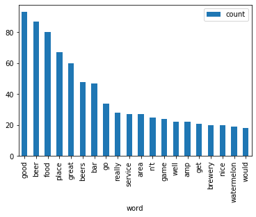

```python
import pandas as pd

# create a dataframe
df = pd.DataFrame(items, columns = ['word', 'count'])

# sort data
df_sort = df.sort_values(by=['count'], ascending=False)

# get first 20 words
df_sort_20 = df_sort.iloc[:20, :]

# bar plot
df_sort_20.plot.bar(x = 'word', y = 'count')
```

## 2.10 WordCloud

Now let's learn how to make a word cloud. First, we need to download two new libraries. Here we introduce a way to execute Terminal commands in the notebook cells. Simply, we prepend an exclamation mark(!) to the beginning of the command. This is very useful when installing a library without having to open a Terminal/Command Prompt.

```python
! pip install wordcloud
```

```python
! pip install imageio
```

In addition, we need a shape/mask image for a word cloud ('mask_heart.png'). We load this mask image using *imageio.imread()*.

```python
import imageio
mask_image = imageio.imread('mask_heart.png')
```

Then, we create a WordCloud object as follows. The colormap options can be found in here https://matplotlib.org/3.1.1/gallery/color/colormap_reference.html.

```python
from wordcloud import WordCloud
wordcloud = WordCloud(colormap = 'prism', mask = mask_image, background_color = 'white')
```

To link the word cloud to the text, we use *.generate()* and put the text variable in it.

```python
wordcloud = wordcloud.generate(text)
```

At last, to save the figure, we use *.to_file()* on the wordcloud object.

```python
wordcloud.to_file('review.png')
```

```
<wordcloud.wordcloud.WordCloud at 0x199f121c1d0>
```

We can also display the plot inside the notebook using *matplotlib.pyplot* and its *.imshow()* function.

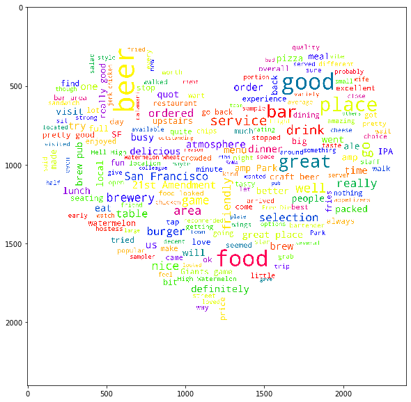

```python
%matplotlib inline
import matplotlib.pyplot as plt

plt.figure(figsize=(10,10))
plt.imshow(wordcloud)
```